# Cox proportional hazards - Study Attrition

## Identify participant features that predict study attrition

### Data pre-processed by amha_data_preprocessing.ipynb

Retention Analysis - One model with Age, Sex, Race, Education, Ethnicity, Gina, AgeOnset

Response Rate - logit(transform) 1) whole study period 2) survey / days in study

'Cleaned Data'  
'EQ Survey Counts'  
'Weekly Survey Counts'  
'Daily Survey Counts'  
'Cohorts'  
'Cox Proportional Hazards Analysis'  
'Figure 2d: Study Retention By Enrollment Month'  
'Figure 2e: Study Retention By Age'  
'Suppl. Figure 2a: Predictor Correlation Heatmap '  
'Suppl. Figure 2b: Response Rate Histogram'  
'Supplementary Table 4a: univariate'  
'Supplementary Table 4b: multivariate'  
'Supplementary Table 4c: OLS'  
'Supplementary Figure 3: Heatmaps'

# Libraries

```python
import pandas as pd
import seaborn as sns
import os, sys
%config InlineBackend.figure_format = 'retina'
%matplotlib inline
%pylab inline
import seaborn
seaborn.set(rc={'axes.facecolor':'white', 'figure.facecolor':'white', 'grid.color':'lightgrey'}\
            , font_scale=1)

rcParams['text.color'] = 'black'
rcParams['ytick.color'] = 'black'
rcParams['xtick.color'] = 'black'
rcParams['axes.facecolor'] = 'white'
rcParams['axes.edgecolor'] = 'white'
```

# Statistical Functions

```python
def construct_contingency_table(df, x, y):
    '''
    This function creates a contingency table
    using values from columns x and y in df
    '''
    return df.groupby([x,y])['conting_count'].sum().unstack()

def cramersV_from_df(df, x, y):
    '''
    This function returns cramersV using
    values from columns x and y in df
    '''
    from scipy import stats
    df['conting_count'] = 1
    contingency_df = df.groupby([x,y])['conting_count'].sum().unstack().values
    chi2, p, ddof, expected = stats.chi2_contingency(contingency_df)
    CV = np.sqrt(chi2 / len(df[x]) * (min(len(df[x].unique()), len(df[y].unique())) -1 ))
    return CV

def cramersV(contingency_df, x_sum, x_unique, y_unique):
    '''
    This function calculates cramersV
    from the values of a N x 2 contingency table table
    '''
    from scipy import stats
    chi2, p, ddof, expected = stats.chi2_contingency(contingency_df)

    CV = np.sqrt(chi2 / (x_sum * (min(x_unique, y_unique) -1 )))
    return CV
```

# Functions

```python
def strip_brackets(series):

    def bracket_repalce(x):
        if x == '[]':
            return np.NaN
        else:
            return x.rstrip(']').lstrip('[')

    series =  [bracket_repalce(i) if type(i)==str else i for i in series]
    try:
        return map(int, series)
    except:
        return series
```

```python
def get_count(vector):
    '''
    This function counts booleans
    '''
    if True in vector or False in vector:
        return [1 if i in [True, False] else 0 for i in vector]

    vector_counts = []
    for i in vector:
        if i == '[]':
            vector_counts.append(0)
            continue
        if i > -1:
            vector_counts.append(1)
            continue
        vector_counts.append(0)

    return vector_counts
```

```python
def get_duplicates(df, col, date, id_name='healthCode'):
    '''
    This function returns a dataframe with duplicate
    entries ordered by time

    '''


    df.sort(date, inplace=True)

    dups = df.reset_index()[[id_name, col]].dropna().drop_duplicates()[id_name].value_counts()
    dups = dups[dups>1]
    df = df.ix[dups.index].set_index(date, append=True)[col]
    return df
```

```python
metadata_cols = ['recordId', 'createdOn', 'appVersion', 'ROW_VERSION', 'uploadDate', 'ROW_ID']
set(metadata_cols)

def data_columns(cols, metadata_cols=['recordId', 'createdOn', 'appVersion', \
                                      'ROW_VERSION', 'uploadDate', 'ROW_ID',\
                                     'phoneInfo']):

    return list( set(cols) - set(metadata_cols))



def get_data(df, cols):

    return df[data_columns(cols)]
```

```python
def select_date(df, date_col, year_month_day):
    '''
    This function returns a subset of the data
    with the date_col < year_month_day
    '''

    year, month, day = year_month_day
    return df[df[date_col] < pd.datetime(year, month, day).date()]
```

## Data

```python
def get_table_columns(dir_path='./test_data/'):
    '''
    This function creates a dictionary of table columns
    indexed on table name
    '''

    csvs = [i for i in os.listdir(dir_path) if i.endswith('csv')]

    table_columns = dict()
    for i in csvs:
        table_columns[i.rstrip('.csv')] = list(set(pd.read_table(dir_path + i, sep=',', nrows=1).columns.tolist()) - set(['healthCode','externalId']))
    return table_columns
```

```python
table_columns = get_table_columns()


def get_table_responses(df, table, table_cols=table_columns):
    '''
    This function returns table rows with at least
    one non-Na value
    '''
    return df.ix[table][table_columns[table]].dropna(how='all')

table_columns
```

```
{'AboutYou': ['education',
  'recordId',
  'createdOn',
  'appVersion',
  'smoking_status',
  'ROW_VERSION',
  'race',
  'smoking_years',
  'uploadDate',
  'ethnicity',
  'Income',
  'phoneInfo',
  'ROW_ID',
  'health_insurance',
  'avg_cigarettes'],
 'AsthmaDailyPrompt': ['get_worse',
  'quick_relief_puffs',
  'day_symptoms',
  'createdOn',
  'appVersion',
  'medicine_change',
  'recordId',
  'ROW_VERSION',
  'uploadDate',
  'night_symptoms',
  'medicine',
  'phoneInfo',
  'ROW_ID',
  'use_qr',
  'peakflow'],
 'AsthmaHistory': ['doc_times',
  'nights',
  'intubated',
  'emergency',
  'times_hospitalized',
  'recordId',
  'limited activity',
  'createdOn',
  'appVersion',
  'age_when_diagnosed',
```

[output cut: 151 more lines]

```
  'flushot',
  'phoneInfo',
  'asthma_control',
  'ROW_ID',
  'uploadDate'],
 'aqiResponse': ['aqiResponse.json.reporting_area',
  'aqiResponse.json.reports',
  'recordId',
  'createdOn',
  'appVersion',
  'ROW_VERSION',
  'uploadDate',
  'aqiResponse.json.state_code',
  'phoneInfo',
  'ROW_ID']}
```

```python
#Common columns across tables
from collections import Counter
c = Counter([n for i in table_columns.keys() for n in table_columns[i] ])
c.most_common(10)
```

```
[('recordId', 11),
 ('appVersion', 11),
 ('phoneInfo', 11),
 ('createdOn', 11),
 ('ROW_VERSION', 11),
 ('ROW_ID', 11),
 ('uploadDate', 11),
 ('quick_relief_puffs', 1),
 ('alleviate_troubles', 1),
 ('emergency_times', 1)]
```

## Cohorts

'Table of Contents'

```python
# Gina classifications

cohort = pd.read_table('../analysis/cohorts_first.tsv',sep='\t')
cohort.columns = ['cohort','healthCode', 'gina']
cohort['gina'] = cohort['gina'].str.replace(' ', '')

baseline = cohort[cohort.cohort=='baseline']
baseline.name = 'baseline'

robust = cohort[cohort.cohort=='robust']
robust.name = 'robust'

milestone = cohort[cohort.cohort=='milestone']
milestone.name = 'milestone'
```

## Clean Synapse Data

'Table of Contents'

```python
#SAGE DATA
df_filtered = pd.read_table('../analysis/sage_data_df_filtered_2015_12_04.txt.gz',sep='\t', compression='gzip',\
                           index_col=['table', 'healthCode'])

df_filtered['study_entry'] = pd.to_datetime(df_filtered.study_entry)
df_filtered['date'] = pd.to_datetime(df_filtered.date)

#study entry for each healthcode
study_entry = select_date(df_filtered.ix['AsthmaDailyPrompt'], 'date', (2015,9,10)).study_entry.dt.date
study_entry = study_entry.reset_index().drop_duplicates().set_index('healthCode')

#df_filtered = select_date(df_filtered, 'date', (2015,9,10))
#df_filtered = df_filtered[df_filtered.index.get_level_values(1).isin(baseline.healthCode)]
```

```python
#Setting entry data to 3-23
entry_date = df_filtered.groupby(level=1)['date'].min()
entry_date= entry_date.reset_index().set_index(pd.DatetimeIndex(entry_date))
entry_date_daterange = entry_date['2015-3-23':'2015-3-29'].healthCode.unique()
entry_date_daterange.shape
```

```
(310,)
```

```python
#Baseline Data

baseline_data = pd.read_table('../analysis/baseline_first_survey_nicole_2015_12.tsv.gz',sep='\t',\
                             compression='gzip', index_col='healthCode')
baseline_data.info()
```

```
<class 'pandas.core.frame.DataFrame'>
Index: 6363 entries, 000152e4-c14d-4e0e-8bc4-d96e53acc868 to ffee35de-8a9e-4105-a3fa-b9cd870cabe5
Data columns (total 71 columns):
doc_times                               2183 non-null float64
nights                                  6192 non-null float64
emergency                               6191 non-null object
times_hospitalized                      6187 non-null object
miss_work                               6186 non-null float64
emergency_times                         701 non-null float64
age_when_diagnosed                      6055 non-null float64
symptoms                                6194 non-null float64
hospitalized_times                      394 non-null float64
intubated                               6187 non-null float64
createdOn_His_data_2015_12_08           6240 non-null object
limited activity                        6193 non-null float64
seen_doc                                6188 non-null object
oral steroids                           6162 non-null float64
past_month_quick_relief                 5861 non-null float64
flovent_hfa_dose                        361 non-null float64
advair_diskus_dose                      950 non-null float64
symbicort_dose                          662 non-null float64
controlmed                              3420 non-null float64
createdOn_Med_data_2015_12_08           5898 non-null object
quick_relief                            5651 non-null object
advair_hfa_dose                         211 non-null float64
qvar_dose                               345 non-null float64
asmanex_dose                            148 non-null float64
steroid_dose                            515 non-null float64
daily_controller_medication             3887 non-null object
daily_yes                               5699 non-null float64
alvesco_dose                            48 non-null float64
daily_inhaled_medicine                  3435 non-null float64
flovent_diskus_dose                     72 non-null float64
prescribed_asthma_control_medication    5860 non-null float64
pulmicort_dose                          171 non-null float64
dulera_dose                             362 non-null float64
steroid_which                           3879 non-null float64
chronic_pulmonary_diesease              3749 non-null object
heart_attack                            3767 non-null object
createdOn_MedH_data_2015_12_08          3775 non-null object
```

[output cut: 21 more lines]

```
createdOn_You_data_2015_12_08           4274 non-null object
education                               4234 non-null float64
avg_cigarettes                          920 non-null float64
asthma_gets_worse_with                  4472 non-null object
lung_function                           4467 non-null float64
troubles_about_asthma                   4460 non-null object
peak_flow                               765 non-null float64
flu_prompt                              2223 non-null object
aap_prompt                              3538 non-null object
flushot                                 4468 non-null object
createdOn_YouA_data_2015_12_08          4494 non-null object
asthma_control                          4416 non-null object
plan                                    4471 non-null object
dtypes: float64(39), object(32)
memory usage: 3.5+ MB
```

```python
#Age & Sex df
age_sex = pd.read_table('../data/raw_agesex_2015_12_4.tsv',sep='\t')
age_sex.set_index('healthCode', drop=False, inplace=True)
col_dict = dict((i, i.replace('NonIdentifiableDemographics.json.patient', '')) for i in age_sex.columns)
age_sex.rename(columns=col_dict, inplace=True)
age_sex = age_sex.drop_duplicates()
age_sex.sort(columns='createdOn', inplace=True)
age_sex.info()
```

```
<class 'pandas.core.frame.DataFrame'>
Index: 3408 entries, 5288ddee-c1a6-479c-8dc2-307a96ca26df to 094e479f-0d0e-419a-9ddf-308c225105b8
Data columns (total 14 columns):
recordId                                 3408 non-null object
healthCode                               3408 non-null object
externalId                               0 non-null float64
uploadDate                               3408 non-null object
createdOn                                3408 non-null object
appVersion                               3408 non-null object
phoneInfo                                3408 non-null object
WeightPounds                             3405 non-null float64
BiologicalSex                            3252 non-null object
HeightInches                             3405 non-null float64
WakeUpTime                               0 non-null float64
CurrentAge                               3253 non-null float64
GoSleepTime                              0 non-null float64
NonIdentifiableDemographics.json.item    3405 non-null object
dtypes: float64(6), object(8)
memory usage: 399.4+ KB
```

```python
#Biological Sex df
biosex = age_sex[['healthCode', 'BiologicalSex', 'createdOn']].dropna(how='all').drop_duplicates(subset=['healthCode', 'BiologicalSex'])
biosex.sort('createdOn', inplace=True)
biosex = biosex.groupby('healthCode')['BiologicalSex'].value_counts().reset_index().drop_duplicates('healthCode').set_index('healthCode')['BiologicalSex']
```

```python
#Age df
age = age_sex[['healthCode', 'CurrentAge', 'createdOn']].dropna(how='all').drop_duplicates(subset=['healthCode', 'CurrentAge'])
age = age[~age.CurrentAge.isnull()]
age.sort('createdOn', inplace=True)
age = age.groupby('healthCode')['CurrentAge'].value_counts().reset_index().drop_duplicates('healthCode').set_index('healthCode')['CurrentAge']
print age.shape
```

```
(2109,)
```

## Daily & Weekly Surveys Collapsed

```python
#SAGE DATA
daily_weekly_df = pd.read_table('../analysis/daily_weekly_prompt_data_collapsed_2015_12_04.tsv.gz',\
                           sep='\t', compression='gzip', index_col=['healthCode', 'study_day'])

daily_weekly_df = daily_weekly_df.join(study_entry, how='left')

daily_weekly_df['dateTime'] = daily_weekly_df.dateTime.map(pd.to_datetime)  #entered study
daily_weekly_df['date'] = pd.to_datetime(daily_weekly_df.dateTime).dt.date
daily_weekly_df['study_entry'] = pd.to_datetime(daily_weekly_df.study_entry, unit='ms')
```

```python
len(daily_weekly_df[daily_weekly_df.date>pd.datetime(2015,3,3).date()].index.get_level_values(0).unique())
```

```
6515
```

# Cox Proportinal Hazards

'Table of Contents'

```python
days_till_2015_09_09 = pd.datetime(2015,9,8).date() - daily_weekly_df.reset_index().drop_duplicates(subset=['healthCode', 'study_entry']).set_index('healthCode')['study_entry'].dropna()
days_till_2015_09_09 = days_till_2015_09_09.dt.days.groupby(level=0).max().dropna()
days_till_2015_09_09.name = 'days_till_2015_09_09'
days_till_2015_09_09.shape

#restricting analysis to those in study for at least 180 days
days_till_2015_09_09_180days = days_till_2015_09_09[days_till_2015_09_09>179]
days_till_2015_09_09_180days.name = 'days_till_2015_09_09'
```

```python
#More efficient way to find censored healthCodes
daily_weekly_df_ts = daily_weekly_df.reset_index().set_index(pd.DatetimeIndex(daily_weekly_df.dateTime))
censored_healthcodes = daily_weekly_df_ts['2015-8-27':'2015-9-8'].healthCode.unique()
print censored_healthcodes.shape, 'censored healthCodes'

entered_before_june = daily_weekly_df_ts[:'2015-6-8'].healthCode.unique()
print entered_before_june.shape, 'entered before June'
```

```
(260,) censored healthCodes
(5768,) entered before June
```

## Creation of dataframes for Multivariate Cox Analysis

```python
import lifelines
from lifelines import CoxPHFitter
from lifelines.datasets import load_regression_dataset
from lifelines.utils import k_fold_cross_validation
pd.set_option('display.precision',4)

def study_entry_month_calendar(date):
    if date.day > 8:  #march 10
        return date.month - 3
    return date.month - 4

regression_dataset = load_regression_dataset()
cf = CoxPHFitter(normalize=False)


aboutyou = baseline_data.copy()
study_entry_month = df_filtered.study_entry.map(study_entry_month_calendar).reset_index(level=0, drop=True)
study_entry_month = study_entry_month.reset_index().drop_duplicates().set_index('healthCode')
study_entry_month.columns = ['study_entry_month']


study_entry_week = df_filtered.date - pd.datetime(2015,03,9)
study_entry_week = study_entry_week.dt.days
study_entry_week = study_entry_week.map(lambda x: 180 if x > 180 else x)
study_entry_week = pd.cut(study_entry_week,bins=range(0,365,14), retbins=False, labels=False)
study_entry_week.name = 'study_entry_week'
study_entry_week.reset_index(0, drop=True, inplace=True)
study_entry_week = study_entry_week.groupby(level=0).min().astype(float)


daily_survey_q = ['quick_relief_puffs', 'medicine', 'day_symptoms', \
                  'night_symptoms', 'peakflow', 'get_worse', \
                  'use_qr', 'medicine_change']


daily_prompt_data_cols = ['quick_relief_puffs', 'medicine', 'get_worse', \
                          'day_symptoms', 'night_symptoms', 'peakflow', \
                          'value', 'study_day', 'createdOn', 'dateTime',\
                         'use_qr', 'medicine_change']


daily_survey_standardqs = [ 'day_symptoms', 'night_symptoms', 'peakflow', \
                           'get_worse', 'use_qr']


cox_cols = [ 'gina','last_survey_censored',   \
            'event_observed', 'education', \
             'age_when_diagnosed', 'Income', \
             'health_insurance', 'ethnicity',\
            'CurrentAge', 'BiologicalSex',\
           'study_entry_month']


print 'Columns in multivariate CoxPH Model\n', cox_cols


#int values
last_study_day = daily_weekly_df[daily_survey_standardqs].dropna(how='all').reset_index().groupby('healthCode')['study_day'].max()
last_study_day = last_study_day.map(lambda x: 180 if x > 179 else x)
last_study_day.name = 'last_survey_censored'


#restricting to entrants before June
last_study_day = last_study_day[last_study_day.index.isin(entered_before_june)]


#print last_study_day.shape
last_study_day = aboutyou.join(last_study_day)  #joining about you data
last_study_day = last_study_day.join(study_entry_month)  #joining study entry month data
last_study_day = last_study_day.join(biosex)  #joining biological sex data
last_study_day = last_study_day.join(age, how='inner') #joining age data
#print last_study_day.shape, 'after age sex joining'

last_study_day = last_study_day[last_study_day.index.isin(days_till_2015_09_09.index)]  #restricting data up to 9/9/2015
#print last_study_day.shape
last_study_day = last_study_day.join(days_till_2015_09_09, how='inner')


#restricting to robust users
last_study_day = last_study_day.join(robust.drop_duplicates().set_index('healthCode')['gina'], how='inner')


#adding censoring data
last_study_day['event_observed'] = [False if i in censored_healthcodes else True for i in last_study_day.index]

#print last_study_day.shape
cox_df = last_study_day[cox_cols].dropna(how='any')

#print cox_df.shape

replacement_dict = {'gina':{'Uncontrolled':2, 'PartlyControlled':1, 'WellControlled':0},\
                    'education':{'1':1, '2':1, '3':1, '4':2, '5':2, '6':3, '7':3, '8':np.NaN},\
                    'BiologicalSex':{'Female':0, 'Male':1},\
                   'health_insurance':{'3':0, '1':1, '2':1, '4':np.NaN},}
    #Nicoles: 'education':{'1':1, '2':1, '3':2, '4':3, '5':3, '6':4, '7':4, '8':np.NaN}

# replacement_dict = {'gina':{'Uncontrolled':2, 'PartlyControlled':1, 'WellControlled':0},\
#                     'BiologicalSex':{'Female':0, 'Male':1}}

cox_df['education'] = cox_df['education'].astype(int).astype(str)
cox_df['health_insurance'] = cox_df['health_insurance'].astype(int).astype(str)
cox_df.replace(to_replace=replacement_dict, inplace=True)
cox_df['education'] = cox_df['education'].astype(float)



print
print 'Sample size before filtering on missing education, income, health insurance, ethnicity, and current age\n', cox_df.shape
print
cox_df = cox_df[(cox_df.education < 8) & \
                (cox_df.Income < 6) & \
                (cox_df.health_insurance < 4) & \
               (cox_df.ethnicity <3) & \
               (cox_df.CurrentAge > 0)] #

print 'Sample size after filtering on missing education, income, health insurance, ethnicity, and current age\n', cox_df.shape
print


cox_df['Current_Age_binned'] = pd.cut(cox_df['CurrentAge'], range(0,100,10), labels=False, retbins=False)
#cox_df = cox_df[cox_df.age_when_diagnosed<20]

cox_df[list( set(cox_df.columns) - set(cox_cols)  )]


#cox_df = cox_df.join(study_entry_week, how='inner')
#cox_cols.append('study_entry_week')

scores = k_fold_cross_validation(cf, cox_df, 'last_survey_censored', event_col='event_observed', k=5)

#Five fold cross validation iteration scores
# print
# print scores
# print mean(scores)
# print std(scores)
```

```
Columns in multivariate CoxPH Model
['gina', 'last_survey_censored', 'event_observed', 'education', 'age_when_diagnosed', 'Income', 'health_insurance', 'ethnicity', 'CurrentAge', 'BiologicalSex', 'study_entry_month']

Sample size before filtering on missing education, income, health insurance, ethnicity, and current age
(620, 11)

Sample size after filtering on missing education, income, health insurance, ethnicity, and current age
(537, 11)
```

```python
#Fitting Multivariate Cox PH model

m = cf.fit( cox_df[cox_cols], \
               'last_survey_censored', event_col='event_observed',\
              ) #
m_summary = m.summary
m_summary['abs_z'] = m_summary['z'].map(np.abs)
m_summary.sort(columns=['abs_z'], ascending=False, inplace=True)
del m_summary['abs_z']
#m_summary = m_summary.apply(np.round, args=[3])

#exp(coef) is the hazard ratio
#coef is the increase in having the event for every 1 unit increase in X
#    therefore if coef is negative then the predictor decreases the hazard of an outcome
```

```python
#CramersV Correlations between categorical variables
cox_cols_categ = ['health_insurance', \
                  'ethnicity', 'BiologicalSex']
cramersV_df = []
for categ1 in cox_cols_categ:
    cramersV_df.append([])
    for categ2 in cox_cols_categ:
        cramersV_df[-1].append(cramersV_from_df(cox_df, categ1, categ2))
cramersV_df =  pd.DataFrame(cramersV_df, columns=cox_cols_categ, index=cox_cols_categ)
cramersV_df
```

|  | health_insurance | ethnicity | BiologicalSex |
| --- | --- | --- | --- |
| health_insurance | NaN | 0.0167 | 0.0061 |
| ethnicity | 0.0167 | NaN | 0.0413 |
| BiologicalSex | 0.0061 | 0.0413 | NaN |

# Supplementary Figure 2a

## Predictor Correlation Heatmaps

'Table of Contents'

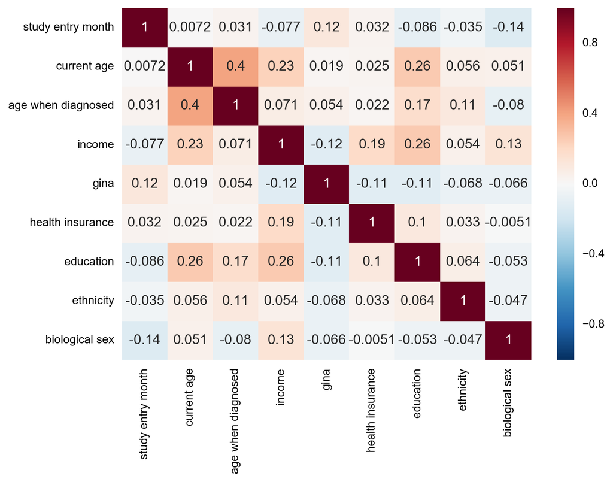

```python
#Covariance Matrix for Numeric Predictors (Standardized)
#Pearson's correlation
cov_df_numeric = cox_df[['study_entry_month', 'CurrentAge', 'age_when_diagnosed', 'Income', 'gina', 'health_insurance','education', 'ethnicity', 'BiologicalSex']]
cov_df_numeric = cov_df_numeric.corr()
cov_df_numeric.columns = [i.replace('_', ' ').replace('CurrentAge', 'current age').replace('BiologicalSex', 'biological sex').lower() for i in cov_df_numeric.columns]
cov_df_numeric.index = [i.replace('_', ' ').replace('CurrentAge', 'current age').replace('BiologicalSex', 'biological sex').lower() for i in cov_df_numeric.columns]

cov_df_numeric_heatmap = seaborn.heatmap(cov_df_numeric, annot=True)
```

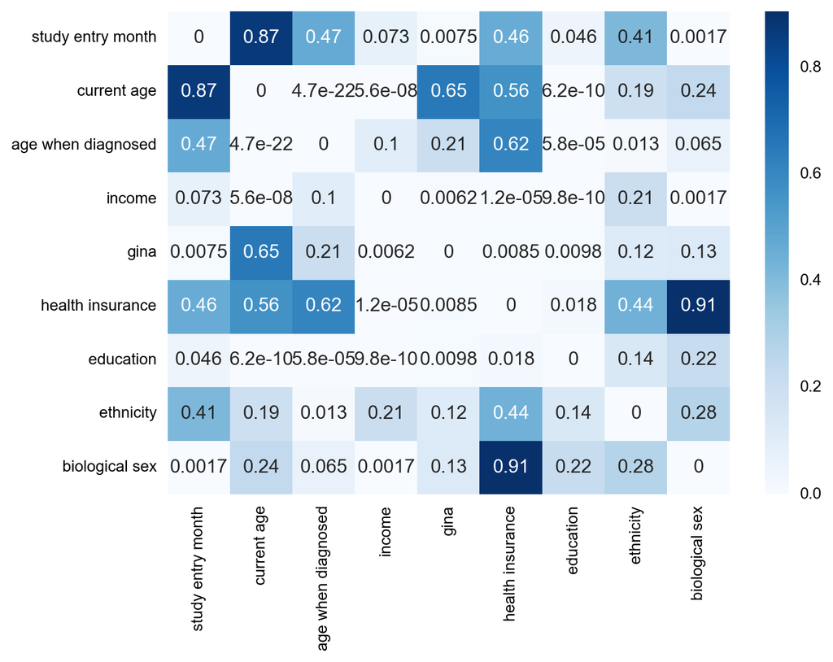

```python
#Pearson's p-value
from scipy import stats
cov_df = cox_df[['study_entry_month', 'CurrentAge', 'age_when_diagnosed', 'Income', 'gina', 'health_insurance','education', 'ethnicity', 'BiologicalSex']]

cor_pval = []
for c1 in cov_df.columns:
    cor_pval.append([])
    for c2 in cov_df.columns:
        cor_pval[-1].append(stats.pearsonr(cov_df[c1], cov_df[c2])[-1])
cor_pval = pd.DataFrame(cor_pval, columns=cov_df.columns, index=cov_df.columns)
cor_pval.columns = [i.replace('_', ' ').replace('CurrentAge', 'current age').replace('BiologicalSex', 'biological sex').lower() for i in cor_pval.columns]
cor_pval.index = [i.replace('_', ' ').replace('CurrentAge', 'current age').replace('BiologicalSex', 'biological sex').lower() for i in cor_pval.columns]
seaborn.heatmap(cor_pval, annot=True, cmap='Blues')
```

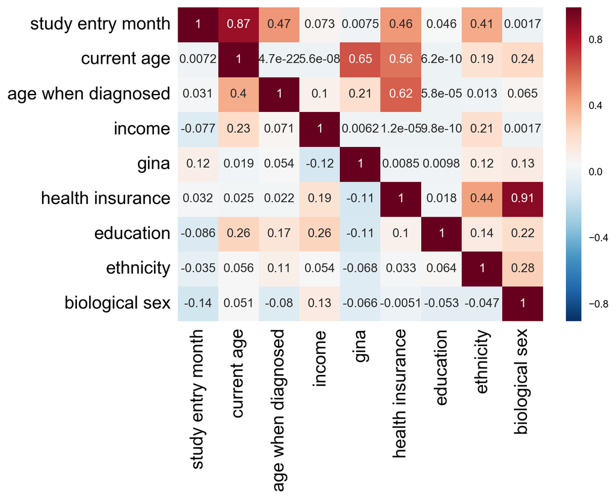

```python
#Merged Figure

def triangle_merge(df_triu, df_tril):
    '''
    Combines values from upper triangle
    and lower triangle from dfs
    '''
    triu = pd.DataFrame(np.triu(df_triu.values))
    triu.replace(0.0, np.NaN, inplace=True)
    tril = pd.DataFrame(np.tril(df_tril))
    tril.replace(0.0, np.NaN, inplace=True)

    combined_df = triu.combine_first(tril)
    combined_df.columns = df_triu.columns
    combined_df.index = df_triu.index
    return combined_df

combined_df = triangle_merge(cor_pval, cov_df_numeric)
seaborn.heatmap(combined_df.replace(0.0, 1.0), annot=True,  center=0.05)
plt.xticks(fontsize='x-large')
plt.yticks(fontsize='x-large')
#plt.tight_layout()
#plt.savefig('/Users/ers/Dropbox/feasibility_figures_ERS/CorrelationMatrix.svg', dpi=600, format='svg')
```

# Supplementary Figure 2b

### Construction of dataframe for Ordinary Least Squares Model

### Data also used for Supplemental Table 4c

'Table of Contents'

```python
#DATAFRAME CONSTRUCTION FOR ORDINARY LEAST SQUARES MODEL


import numpy as np
import statsmodels.api as sm
import statsmodels.formula.api as smf
from scipy.special import logit

daily_survey_standardqs = [ 'day_symptoms', 'night_symptoms', 'peakflow', \
                           'get_worse', 'use_qr']



#number of days in study fory each healthcode
days_in_study_2015_9_9 = select_date(daily_weekly_df, 'date', (2015,9,8))

days_in_study_2015_9_9 = days_in_study_2015_9_9.study_entry.dt.date
days_in_study_2015_9_9 = pd.to_datetime(days_in_study_2015_9_9, unit='ms')
days_in_study_2015_9_9 = pd.datetime(2015,9,8) - days_in_study_2015_9_9
days_in_study_2015_9_9 = days_in_study_2015_9_9.dt.days
days_in_study_2015_9_9.name = 'days_in_study_2015_9_9'
days_in_study_2015_9_9.sort(inplace=True, ascending=False)
days_in_study_2015_9_9 = days_in_study_2015_9_9.reset_index().drop_duplicates().set_index('healthCode')


days_till_2015_09_09 = pd.datetime(2015,9,8).date() - daily_weekly_df['study_entry'].dropna()
days_till_2015_09_09 = days_till_2015_09_09.reset_index('healthCode').drop_duplicates().set_index('healthCode')
days_till_2015_09_09_180days = days_till_2015_09_09[days_till_2015_09_09.study_entry.dt.days>90]
days_till_2015_09_09_180days.columns = ['days_till_2015_09_09']
days_till_2015_09_09_180days['days_till_2015_09_09'] = 184 - days_till_2015_09_09_180days['days_till_2015_09_09'].dt.days
days_till_2015_09_09_180days.shape

#DAILY SURVEYS, AT LEAST 1 QUESTION ANSWERED
daily_weekly_df_response = select_date(daily_weekly_df, 'date', (2015,9,8))  #restrict to data before 9/19/2015

#calculate responses per healthcode
daily_survey_response_days = daily_weekly_df_response.query('study_day < 181').dropna(subset=[daily_survey_standardqs], how='all').groupby(level=0)['value'].sum()

#join days in study
daily_survey_response_days = pd.DataFrame(daily_survey_response_days).join(days_in_study_2015_9_9, how='inner')

#calculate rate #days responding / #days enrolled
daily_survey_response_days['ratio'] = daily_survey_response_days['value'].astype(float).divide(daily_survey_response_days['days_in_study_2015_9_9'].values, axis=0)
daily_survey_response_days = daily_survey_response_days.reset_index().drop_duplicates(['healthCode', 'ratio']).set_index('healthCode')
daily_survey_response_days.head()



cohort_response_rate = daily_survey_response_days.join(aboutyou)
cohort_response_rate = cohort_response_rate.join(robust.set_index('healthCode')['gina'], how='inner')

cohort_response_rate['intercept'] = 1


cohort_response_rate = cohort_response_rate.join(days_till_2015_09_09_180days, how='inner')



replacement_dict = {'gina':{'Uncontrolled':2, 'PartlyControlled':1, 'WellControlled':0},\
                    'education':{'1':1, '2':1, '3':1, '4':2, '5':2, '6':3, '7':3, '8':np.NaN},\
                    'BiologicalSex':{'Female':0, 'Male':1},\
                   'health_insurance':{'3.0':0, '1.0':1, '2.0':1, '4.0':np.NaN},}

cohort_response_rate = cohort_response_rate.dropna(subset=['health_insurance'])
cohort_response_rate['education'] = cohort_response_rate['education'].astype(str)
cohort_response_rate['health_insurance'] = cohort_response_rate['health_insurance'].astype(str)
cohort_response_rate.replace(to_replace=replacement_dict, inplace=True)
cohort_response_rate['education'] = cohort_response_rate['education'].astype(float)#.astype(str)


cohort_response_rate = cohort_response_rate[(cohort_response_rate.education<8) ]
cohort_response_rate = cohort_response_rate.join(study_entry_month)

#DATA NORMALIZATION
cohort_response_rate['logit_response_rate'] = cohort_response_rate['ratio'].map(logit)
cohort_response_rate['logit_response_rate'] = cohort_response_rate['logit_response_rate'].map(lambda x: 1.0 if x > 1.0 else x)

def std_scale(x):

    mean_x = np.mean(x)
    std_x = np.std(x)
    return [(i - mean_x) / std_x for i in x]

cohort_response_rate = cohort_response_rate[cohort_response_rate.index.isin(cox_df.index)]
cohort_response_rate = cohort_response_rate.join(age)
cohort_response_rate['Current_Age_binned'] = pd.cut(cohort_response_rate['CurrentAge'], range(0,100,10), labels=False, retbins=False)
cohort_response_rate = cohort_response_rate.join(biosex)

for c in ['education', 'age_when_diagnosed', 'gina', 'CurrentAge', 'ethnicity', 'Income', 'health_insurance','study_entry_month']:
    cohort_response_rate[c + '_stdscale'] = cohort_response_rate[[c]].apply(std_scale)



results = smf.ols('logit_response_rate ~ I(study_entry_month) + I(CurrentAge) + C(health_insurance) + C(ethnicity) + C(BiologicalSex) + I(education_stdscale) ', \
                                  data=cohort_response_rate[cohort_response_rate.index.isin(cox_df.index)]).fit()

results.summary()
```

OLS Regression Results

| Dep. Variable: | logit_response_rate | R-squared: | 0.117 |
| --- | --- | --- | --- |
| Model: | OLS | Adj. R-squared: | 0.107 |
| Method: | Least Squares | F-statistic: | 11.70 |
| Date: | Sun, 29 Jan 2017 | Prob (F-statistic): | 2.48e-12 |
| Time: | 23:27:08 | Log-Likelihood: | -835.29 |
| No. Observations: | 537 | AIC: | 1685. |
| Df Residuals: | 530 | BIC: | 1715. |
| Df Model: | 6 |  |  |
| Covariance Type: | nonrobust |  |  |

|  | coef | std err | t | P>\|t\| | [95.0% Conf. Int.] |
| --- | --- | --- | --- | --- | --- |
| Intercept | -2.1320 | 0.354 | -6.021 | 0.000 | -2.828 -1.436 |
| C(health_insurance)[T.1.0] | 0.6100 | 0.295 | 2.068 | 0.039 | 0.030 1.190 |
| C(ethnicity)[T.2.0] | -0.0958 | 0.152 | -0.631 | 0.528 | -0.394 0.202 |
| C(BiologicalSex)[T.Male] | -0.2541 | 0.104 | -2.449 | 0.015 | -0.458 -0.050 |
| I(study_entry_month) | -0.4409 | 0.076 | -5.802 | 0.000 | -0.590 -0.292 |
| I(CurrentAge) | 0.0230 | 0.004 | 5.702 | 0.000 | 0.015 0.031 |
| I(education_stdscale) | -0.0539 | 0.053 | -1.020 | 0.308 | -0.158 0.050 |

| Omnibus: | 18.452 | Durbin-Watson: | 1.993 |
| --- | --- | --- | --- |
| Prob(Omnibus): | 0.000 | Jarque-Bera (JB): | 9.191 |
| Skew: | -0.078 | Prob(JB): | 0.0101 |
| Kurtosis: | 2.378 | Cond. No. | 345. |

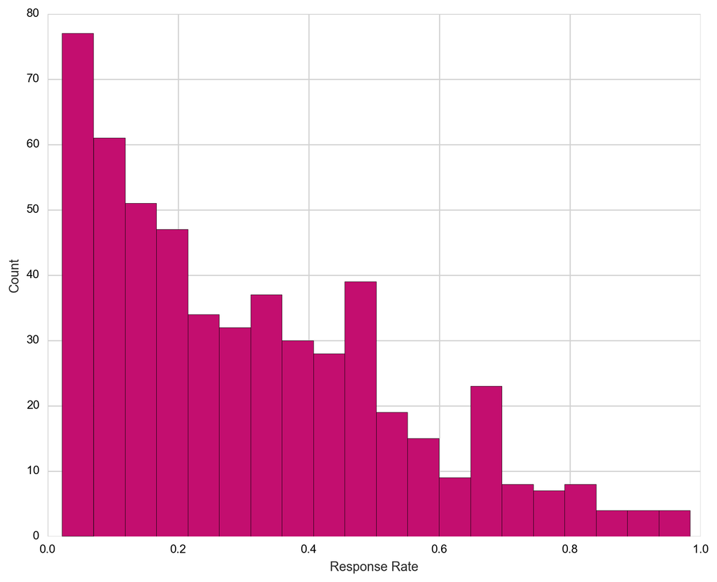

```python
cohort_response_rate[cohort_response_rate.index.isin(cox_df.index)]['ratio'].hist(bins=20, color='#C30E6F', figsize=(10,8))
plt.ylabel('Count')
plt.xlabel('Response Rate')
```

# Univariate Model

## Supplementary Table 4a

## Estimated Cox proportional hazards models for predicting retention time based on univariate analysis.

'Table of Contents'

```python
model_summary_univariate = []
for c in cox_cols:
    print c
    if c in ['last_survey_censored', 'event_observed']: continue
    cf.fit( cox_df[['last_survey_censored', 'event_observed', c]], \
               'last_survey_censored', event_col='event_observed',\
              )

    model_summary = cf.summary
    model_summary.sort(columns=['p'], inplace=True)
    model_summary.index = [i.replace('_', ' ').upper().replace('BIOLOGICALSEX', 'BIOLOGICAL SEX').lower() for i in model_summary.index]
    model_summary['lower 0.95'] = model_summary['lower 0.95'].map(np.exp)
    model_summary['upper 0.95'] = model_summary['upper 0.95'].map(np.exp)

    model_summary_univariate.append( model_summary)

pd.set_option('display.precision',3)
univariate_models = pd.concat(model_summary_univariate)
univariate_models['abs_z'] = univariate_models['z'].map(np.abs)
univariate_models.sort(columns=['abs_z'], ascending=False, inplace=True)
del univariate_models['abs_z']
univariate_models = univariate_models.rename(index={'currentage':'current age'})
univariate_models
```

```
gina
last_survey_censored
event_observed
education
age_when_diagnosed
Income
health_insurance
```

```
ethnicity
CurrentAge
BiologicalSex
study_entry_month
```

|  | coef | exp(coef) | se(coef) | z | p | lower 0.95 | upper 0.95 |
| --- | --- | --- | --- | --- | --- | --- | --- |
| study entry month | 0.637 | 1.891 | 0.075 | 8.523 | 1.559e-17 | 1.633 | 2.189 |
| current age | -0.020 | 0.980 | 0.004 | -4.907 | 9.230e-07 | 0.972 | 0.988 |
| age when diagnosed | -0.009 | 0.991 | 0.004 | -2.423 | 1.541e-02 | 0.984 | 0.998 |
| ethnicity | -0.293 | 0.746 | 0.144 | -2.029 | 4.243e-02 | 0.562 | 0.990 |
| income | -0.089 | 0.915 | 0.045 | -1.995 | 4.606e-02 | 0.838 | 0.998 |
| health insurance | -0.462 | 0.630 | 0.272 | -1.694 | 9.025e-02 | 0.369 | 1.075 |
| education | -0.131 | 0.877 | 0.083 | -1.586 | 1.128e-01 | 0.746 | 1.031 |
| gina | 0.083 | 1.086 | 0.072 | 1.153 | 2.488e-01 | 0.944 | 1.250 |
| biological sex | -0.017 | 0.983 | 0.103 | -0.164 | 8.694e-01 | 0.803 | 1.204 |

# Multivariate Cox PH Model

## Supplemental Table 4b

'Table of Contents'

```python
#Multivariate Cox model
# outcome measurement: number of days until last daily survey completion

pd.set_option('display.precision',4)
m_summary.index = [i.replace('_', ' ').replace('CurrentAge', 'current age').replace('BiologicalSex', 'biological sex').lower() for i in m_summary.index]
m_summary['lower 0.95'] = m_summary['lower 0.95'].apply(np.exp)
m_summary['upper 0.95'] = m_summary['upper 0.95'].apply(np.exp)

m_summary
```

|  | coef | exp(coef) | se(coef) | z | p | lower 0.95 | upper 0.95 |
| --- | --- | --- | --- | --- | --- | --- | --- |
| study entry month | 0.6976 | 2.0089 | 0.0762 | 9.1562 | 5.3751e-20 | 281.9345 | 29840.2139 |
| current age | -0.0226 | 0.9776 | 0.0046 | -4.9031 | 9.4336e-07 | 13.9411 | 14.6123 |
| health insurance | -0.4605 | 0.6310 | 0.2816 | -1.6355 | 1.0194e-01 | 4.2126 | 19.9167 |
| ethnicity | -0.2060 | 0.8138 | 0.1464 | -1.4075 | 1.5928e-01 | 6.3092 | 19.2461 |
| biological sex | 0.0996 | 1.1048 | 0.1077 | 0.9250 | 3.5497e-01 | 11.5421 | 50.1001 |
| age when diagnosed | -0.0037 | 0.9963 | 0.0041 | -0.8985 | 3.6890e-01 | 14.6815 | 15.3366 |
| gina | 0.0609 | 1.0628 | 0.0733 | 0.8305 | 4.0623e-01 | 12.3108 | 30.3105 |
| education | 0.0471 | 1.0483 | 0.0889 | 0.5301 | 5.9603e-01 | 11.1591 | 32.5612 |
| income | -0.0139 | 0.9862 | 0.0489 | -0.2849 | 7.7571e-01 | 11.5836 | 19.3139 |

# Ordinary Least Squares Model

## Supplemental Table 4c

'Table of Contents'

```python
results.summary()
```

OLS Regression Results

| Dep. Variable: | logit_response_rate | R-squared: | 0.117 |
| --- | --- | --- | --- |
| Model: | OLS | Adj. R-squared: | 0.107 |
| Method: | Least Squares | F-statistic: | 11.70 |
| Date: | Fri, 27 Jan 2017 | Prob (F-statistic): | 2.48e-12 |
| Time: | 14:37:23 | Log-Likelihood: | -835.29 |
| No. Observations: | 537 | AIC: | 1685. |
| Df Residuals: | 530 | BIC: | 1715. |
| Df Model: | 6 |  |  |
| Covariance Type: | nonrobust |  |  |

|  | coef | std err | t | P>\|t\| | [95.0% Conf. Int.] |
| --- | --- | --- | --- | --- | --- |
| Intercept | -2.1239 | 0.352 | -6.026 | 0.000 | -2.816 -1.431 |
| C(health_insurance)[T.1.0] | 0.6100 | 0.295 | 2.068 | 0.039 | 0.030 1.190 |
| C(ethnicity)[T.2.0] | -0.0958 | 0.152 | -0.631 | 0.528 | -0.394 0.202 |
| C(BiologicalSex)[T.Male] | -0.2541 | 0.104 | -2.449 | 0.015 | -0.458 -0.050 |
| I(study_entry_month) | -0.4409 | 0.076 | -5.802 | 0.000 | -0.590 -0.292 |
| I(CurrentAge) | 0.0230 | 0.004 | 5.702 | 0.000 | 0.015 0.031 |
| I(education_stdscale) | -0.0564 | 0.055 | -1.020 | 0.308 | -0.165 0.052 |

| Omnibus: | 18.452 | Durbin-Watson: | 1.993 |
| --- | --- | --- | --- |
| Prob(Omnibus): | 0.000 | Jarque-Bera (JB): | 9.191 |
| Skew: | -0.078 | Prob(JB): | 0.0101 |
| Kurtosis: | 2.378 | Cond. No. | 344. |

# CDF of Days in AMHA Study

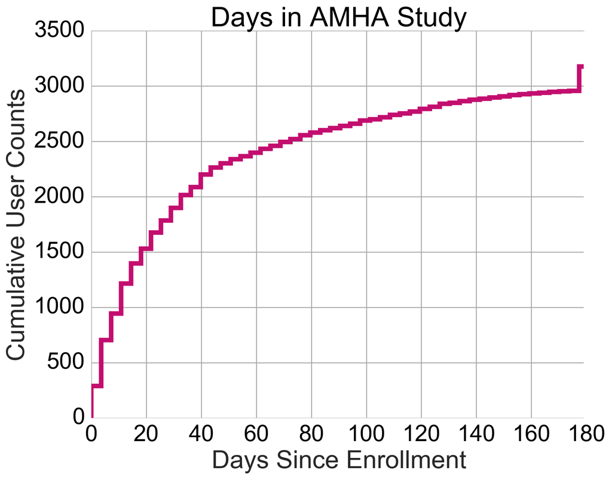

```python
last_study_day = daily_weekly_df[daily_survey_standardqs].dropna(how='all').reset_index().groupby('healthCode')['study_day'].max()
last_study_day = last_study_day.map(lambda x: 181 if x > 179 else x)
last_study_day.name = 'last_survey_censored'

last_study_day.ix[baseline.healthCode].hist(bins=50,  histtype='step', cumulative=True,  linewidth=5, color='#C30E6F', figsize=(10,8))
#plt.xlabel('Enrollment Day')
plt.ylabel('Cumulative User Counts', rotation=90)
plt.xlabel('Days Since Enrollment')
plt.grid(color='darkgray')
plt.title('Days in AMHA Study')
plt.xlim(0,180)
plt.vlines(x=180,ymin=0,ymax=3500, color='white', linewidth=6)
plt.tight_layout()
#plt.savefig('/Users/ers/Dropbox/feasibility_figures_ERS/CumulativeHist_Retention.svg',dpi=600, format='svg')
plt.show()
```

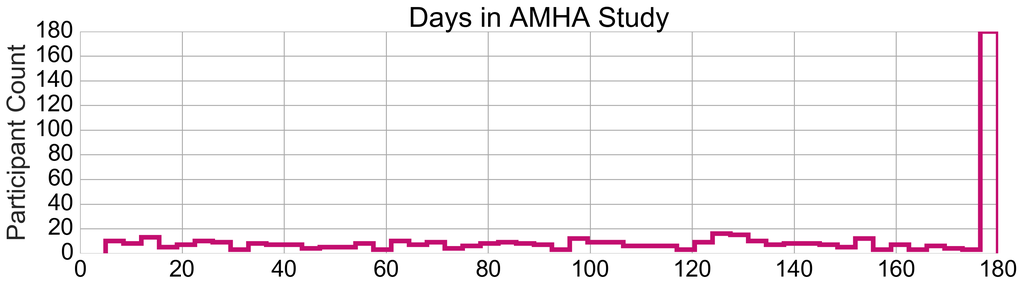

```python
cox_df.last_survey_censored.hist(bins=50, histtype='step', linewidth=5, color='#C30E6F', figsize=(16,5))
plt.ylabel('Participant Count', rotation=90)
plt.grid(color='darkgray')
plt.title('Days in AMHA Study')
plt.tight_layout()
```

# Figure 2d - Enrollment and retention over time for Robust users By Study Entry Month

'Table of Contents'

'cox_df used below created here'

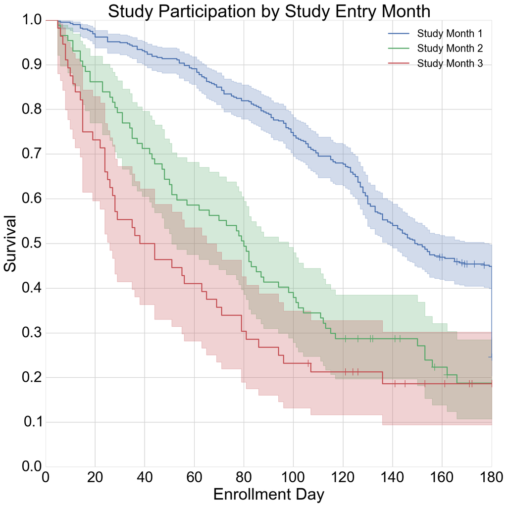

```python
#Baseline
#Kaplan Meier Curve
from lifelines import KaplanMeierFitter
# kmf_control = KaplanMeierFitter()
# kmf_control.fit(last_daily.last_daily.values, label='Asthma App').plot()

#Baseline
from lifelines import KaplanMeierFitter
from lifelines.plotting import add_at_risk_counts

rcParams['text.color'] = 'black'
rcParams['ytick.color'] = 'black'
rcParams['xtick.color'] = 'black'
rcParams['axes.facecolor'] = 'white'
rcParams['axes.edgecolor'] = 'white'

fig, ax = plt.subplots(1,1, figsize=(12,12))
fig.patch.set_facecolor('white')


kmfs = []
row_counter = 0
col_counter = 0
for i,n in cox_df[cox_df.index.isin(robust.healthCode)].groupby(['study_entry_month']):



    kmf_control = KaplanMeierFitter()
    kmf_df = n
    label_dict = {0:'Study Month 1', 1:'Study Month 2', 2:'Study Month 3', 3:'Study Month 4'}
    label_i = label_dict[i]

    kmf_control.fit(kmf_df.last_survey_censored.values, event_observed=kmf_df.event_observed, label=label_i)


    kmf_control.plot(label=i, ax=ax, cmap='jet', show_censors=True)
    kmfs.append(kmf_df)
    ax.set_axis_bgcolor('white')
    ax.set_title('Study Participation by Study Entry Month' )


    ax.set_xlabel('Enrollment Day', color='black')

    ax.set_ylabel('Survival', color='black')

plt.legend(fontsize='xx-large')
plt.tight_layout()
plt.yticks(arange(0,1.1,.1))
plt.savefig('../analysis/feasibility_figures_ERS/KM_by_study.svg', format='svg', dpi=600)
plt.show()
```

# Figure 2e Enrollment and retention over time for Robust users By Age

'Table of Contents'

```
0
1
```

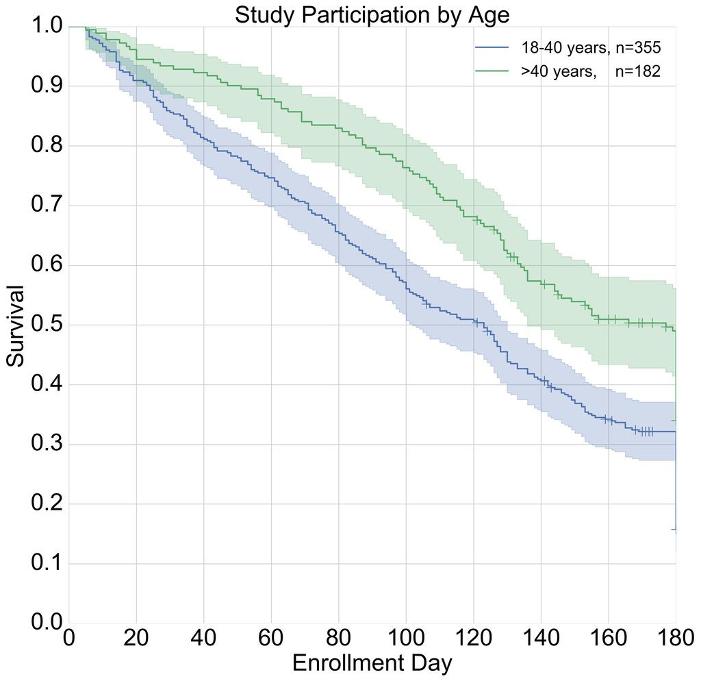

```python
#Baseline
#Kaplan Meier Curve
from lifelines import KaplanMeierFitter

#Baseline
from lifelines import KaplanMeierFitter
from lifelines.plotting import add_at_risk_counts


rcParams['text.color'] = 'black'
rcParams['ytick.color'] = 'black'
rcParams['xtick.color'] = 'black'
rcParams['axes.facecolor'] = 'white'
rcParams['axes.edgecolor'] = 'white'

fig, ax = plt.subplots(1,1, figsize=(12,12))
fig.patch.set_facecolor('white')


kmfs = []
row_counter = 0
col_counter = 0


cox_df_age = cox_df.copy()

cox_df_age['Current Age binned'] = pd.cut(cox_df['CurrentAge'], [0,40,100], labels=False, retbins=False)
for i,n in cox_df_age[cox_df_age.index.isin(baseline.healthCode)].groupby(['Current Age binned']):

    print i
    if n.shape[0] < 10: continue
    kmf_control = KaplanMeierFitter()
    kmf_df = n

    if i ==0:
        label_i = '18-40 years, n=' + str(n.shape[0])
    else:
        label_i = '>40 years,    n=' + str(n.shape[0])
    kmf_control.fit(kmf_df.last_survey_censored.values, event_observed=kmf_df.event_observed, label=label_i)


    kmf_control.plot(label=i, ax=ax, cmap='jet', show_censors=True, ci_show=True)
    kmfs.append(kmf_df)
    ax.set_axis_bgcolor('white')
    ax.set_title('Study Participation by Age', fontsize=30)
    ax.set_ylabel('Survival', fontsize=30)
    ax.set_xlabel('Enrollment Day', fontsize=30)


    ax.set_xlabel('Enrollment Day', color='black')

    ax.set_ylabel('Survival', color='black')
plt.legend(fontsize='xx-large')
plt.tight_layout()
plt.yticks(arange(0,1.1,.1), fontsize=30)
plt.xticks(range(0,200, 20), fontsize=30)
plt.show()
```

# Supplemental Figure 3

'Table of Contents'

## Symptom Heatmaps

### day_symptoms, night_symptoms, use_qr

```
DAY SYMPTOMS
```

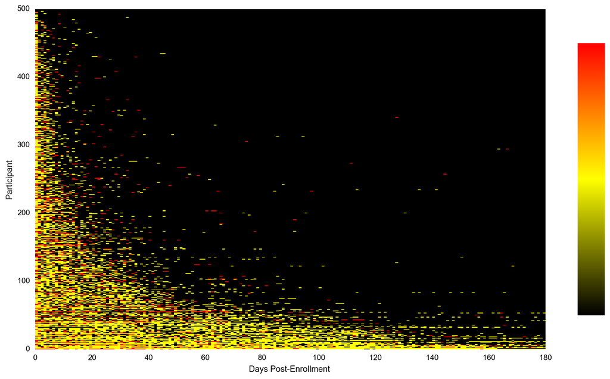

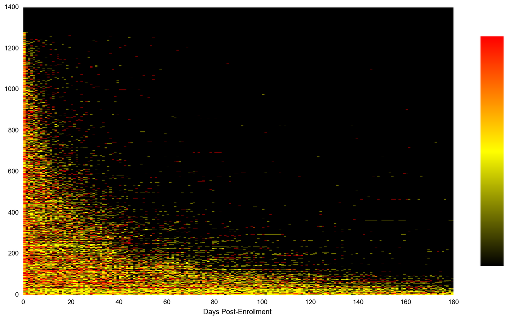

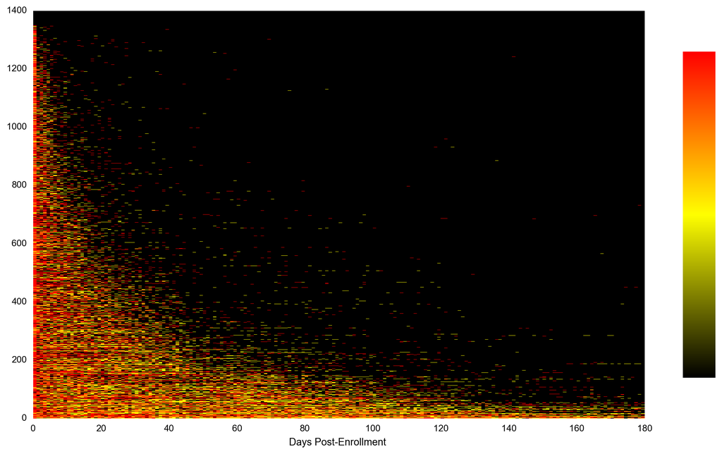

```
NIGHT SYMPTOMS
```

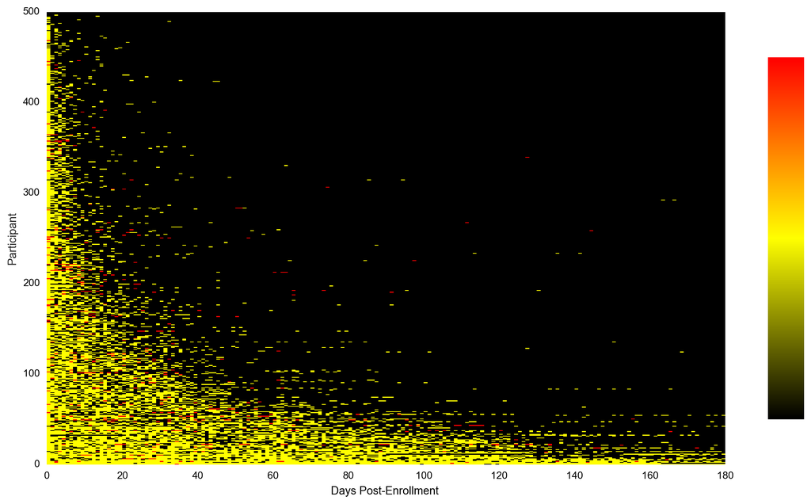

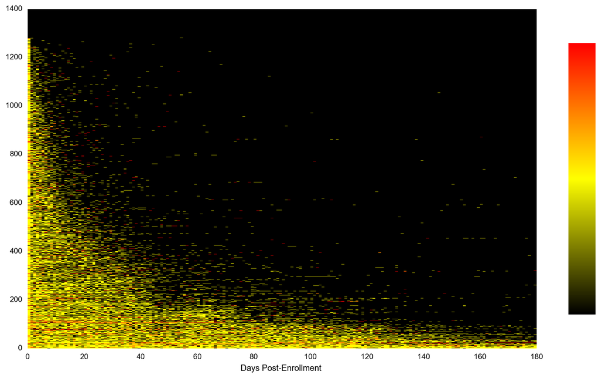

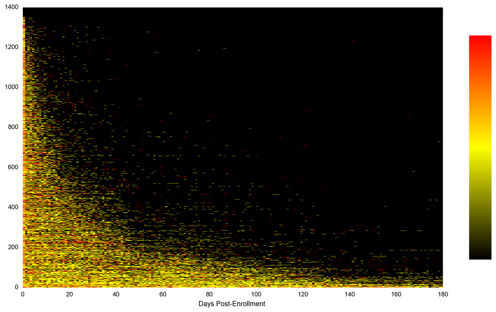

```
USE QR
```

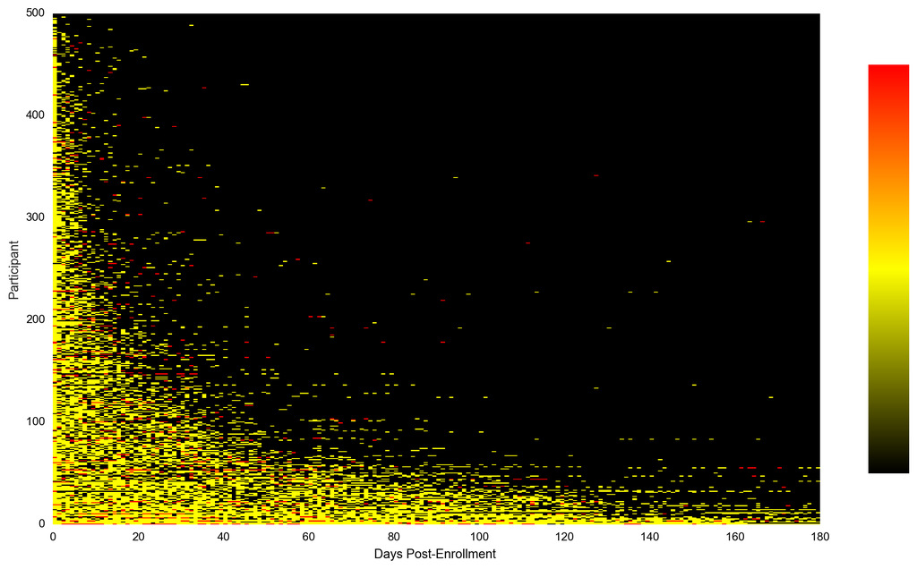

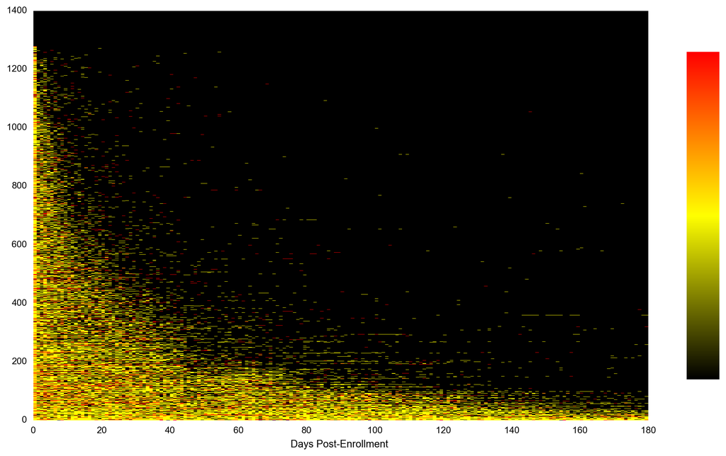

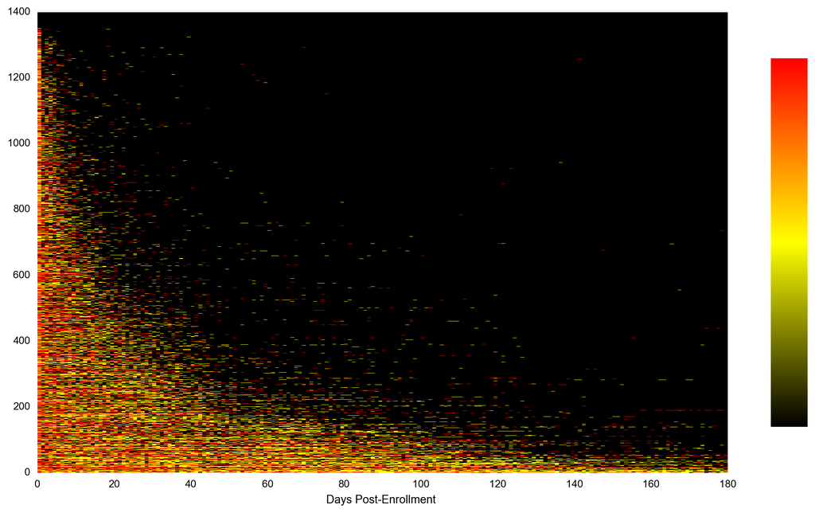

```python
rcParams['text.color'] = 'black'
rcParams['ytick.color'] = 'black'
rcParams['xtick.color'] = 'black'



from matplotlib.colors import LinearSegmentedColormap
vmax = 2.0
cmap = LinearSegmentedColormap.from_list('mycmap', [(0 / vmax, 'black'),
                                                    (1 / vmax, 'yellow'),
                                                    (2 / vmax, 'red')]
                                        )


def heatmap_plot(heatmap_df, title, ylabel=True):
    fig, ax = plt.subplots(1,1, figsize=(15,8))

    heatmap_df = heatmap_df[range(0,180)]

    #Order participants by daily survey completion counts
    heatmap_df_order = heatmap_df.apply(lambda x: sum([1 if i in set([0,1]) else 0 for i in x]), axis=1)
    heatmap_df_order.sort(inplace=True, ascending=False)
    heatmap_df_order


    p = ax.pcolormesh(heatmap_df.ix[heatmap_df_order.index].values, cmap=cmap)


    cbar = fig.colorbar(p, aspect=10,  shrink=0.8, ticks=[-1,0,1])
    cbar.set_ticklabels([''])

    ax.set_xlabel('Days Post-Enrollment ', color='black')
    ax.set_axis_bgcolor('black')


    if ylabel:
        ax.set_ylabel('Participant')


    plt.show()


ids_180days_of_study = days_till_2015_09_09[days_till_2015_09_09>179].index

for n,symptom in enumerate(['day_symptoms', 'night_symptoms', 'use_qr']):

    symptom_title = symptom.replace('_', ' ').upper()
    print symptom_title

    if symptom != 'medicine':
        heatmap_df = daily_weekly_df[symptom].map(sum).reset_index().pivot_table(index='healthCode', columns='study_day', values=symptom)

    else:
        heatmap_df = daily_weekly_df[[symptom]]
        heatmap_df[symptom] = heatmap_df[symptom].map(med_multi_parse)
        heatmap_df = heatmap_df.reset_index().pivot_table(index='healthCode', columns='study_day', values=symptom)

    #LIMITS PLOTS TO PEOPLE IN STUDY FOR AT LEAST 180 DAYS BY 9/9/2015
    heatmap_df = heatmap_df[heatmap_df.index.isin(ids_180days_of_study)]

    wellcontrolled = heatmap_df[heatmap_df.index.isin(baseline[baseline.gina=='WellControlled']['healthCode'].values)]
    heatmap_plot(wellcontrolled, 'Well Controlled,  n='+ str(wellcontrolled.shape[0]), True)

    partlycontrolled = heatmap_df[heatmap_df.index.isin(baseline[baseline.gina=='PartlyControlled']['healthCode'].values)]
    heatmap_plot(partlycontrolled, 'Partly Controlled,  n=' + str(partlycontrolled.shape[0]), False)

    uncontrolled = heatmap_df[heatmap_df.index.isin(baseline[baseline.gina=='Uncontrolled']['healthCode'].values)]
    heatmap_plot(uncontrolled, 'Uncontrolled,  n=' + str(uncontrolled.shape[0]), False)
```

# Daily Controller Medication Usage Heatmap

```
MEDICINE
```

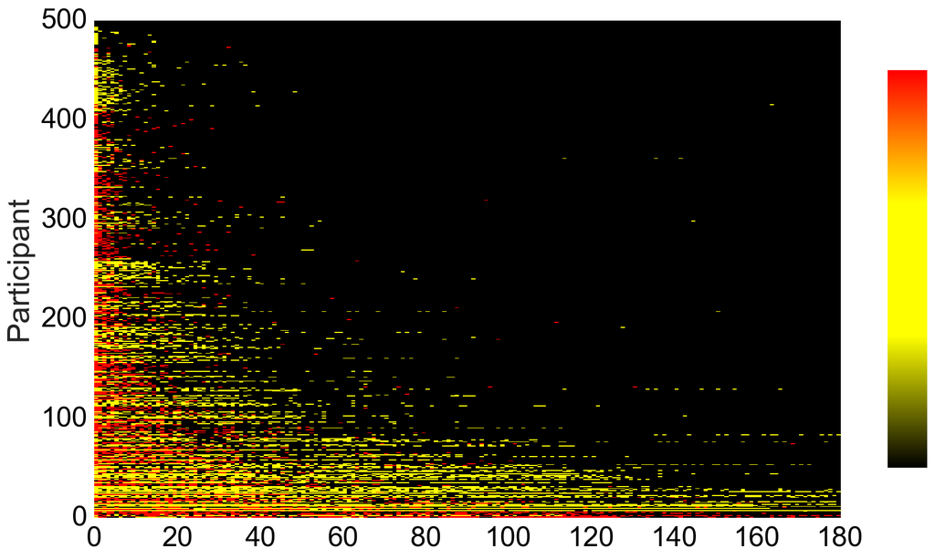

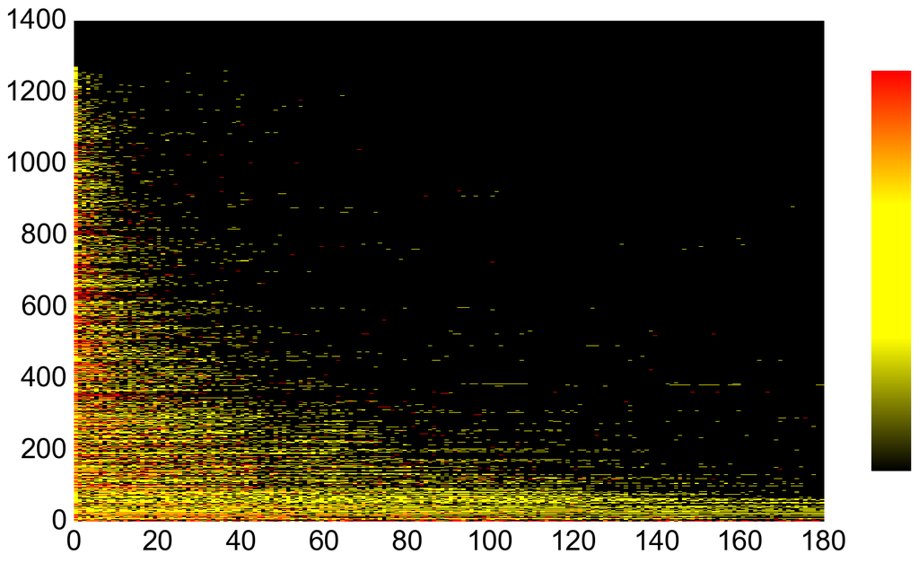

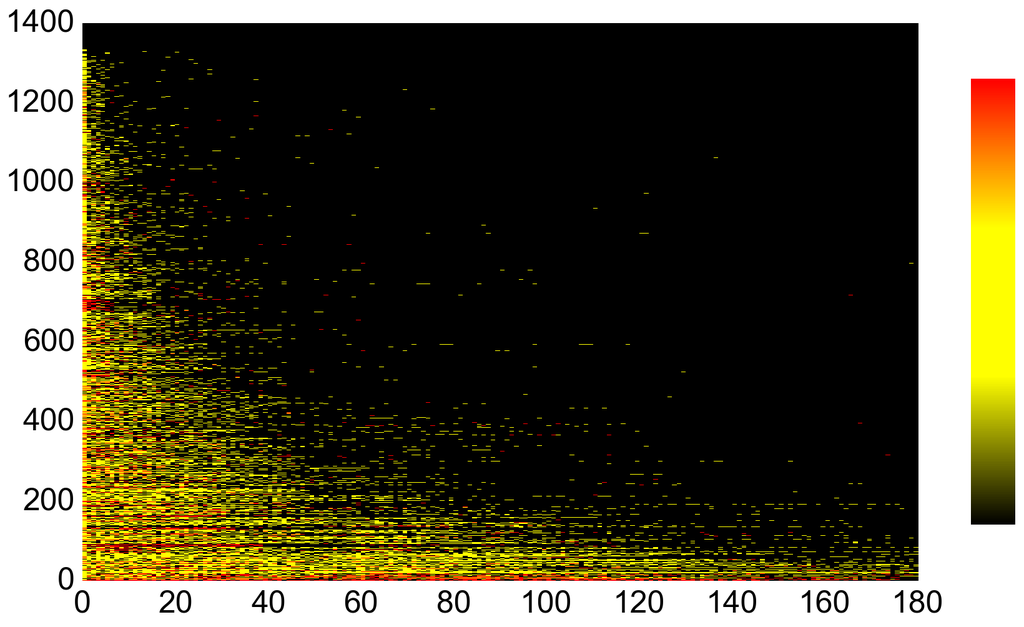

```python
#DAILY CONTROLLER MEDICATION USAGE HEATMAP

rcParams['text.color'] = 'black'
rcParams['ytick.color'] = 'black'
rcParams['xtick.color'] = 'black'



from matplotlib.colors import LinearSegmentedColormap
vmax = 3.0
cmap = LinearSegmentedColormap.from_list('mycmap', [(0 / vmax, 'black'),
                                                    (1 / vmax, 'yellow'),
                                                    (2 / vmax, 'yellow'),
                                                    (3 / vmax, 'red')]

                                        )

def heatmap_plot(heatmap_df, title, ylabel=True):
    fig, ax = plt.subplots(1,1, figsize=(15,8))

    heatmap_df = heatmap_df[range(0,180)]

    #Order participants by daily survey completion counts

    heatmap_df_order = heatmap_df.apply(np.sum, axis=1)
    heatmap_df_order.sort(inplace=True, ascending=False)
    heatmap_df_order


    p = ax.pcolormesh(heatmap_df.ix[heatmap_df_order.index].values, cmap=cmap)


    cbar = fig.colorbar(p, aspect=10,  shrink=0.8, ticks=[0, 1, 2, 3])
    cbar.set_ticklabels([''])

    ax.set_axis_bgcolor('black')


    if ylabel:
        ax.set_ylabel('Participant')


    plt.show()


def med_multi_parse(x):
    if ',' in str(x):
        x = map(float, x.split(','))
        return min(x)
    return float(x)


ids_180days_of_study = days_till_2015_09_09[days_till_2015_09_09>179].index

for n,symptom in enumerate(['medicine']):

    symptom_title = symptom.replace('_', ' ').upper()
    print symptom_title

    if symptom != 'medicine':
        heatmap_df = daily_weekly_df[symptom].map(sum).reset_index().pivot_table(index='healthCode', columns='study_day', values=symptom)

    else:
        heatmap_df = daily_weekly_df[[symptom]]
        heatmap_df[symptom] = heatmap_df[symptom].map(med_multi_parse)
        heatmap_df = heatmap_df[heatmap_df[symptom]!=4]
        heatmap_df = heatmap_df.reset_index().pivot_table(index='healthCode', columns='study_day', values=symptom)

    #LIMITS PLOTS TO PEOPLE IN STUDY FOR AT LEAST 180 DAYS BY 9/9/2015

    heatmap_df = heatmap_df.fillna(0)

    wellcontrolled = heatmap_df[heatmap_df.index.isin(baseline[baseline.gina=='WellControlled']['healthCode'].values)]
    heatmap_plot(wellcontrolled, 'Well Controlled,  n='+ str(wellcontrolled.shape[0]), True)

    partlycontrolled = heatmap_df[heatmap_df.index.isin(baseline[baseline.gina=='PartlyControlled']['healthCode'].values)]
    heatmap_plot(partlycontrolled, 'Partly Controlled,  n=' + str(partlycontrolled.shape[0]), False)

    uncontrolled = heatmap_df[heatmap_df.index.isin(baseline[baseline.gina=='Uncontrolled']['healthCode'].values)]
    heatmap_plot(uncontrolled, 'Uncontrolled,  n=' + str(uncontrolled.shape[0]), False)
```